# Between-Sample (Beta) Diversity of microbes in dairy samples across seasons

Kailyn Hanke

2025-04-26

The goal of this document is to run an analysis on the between-sample (beta) diversity of the samples in my project, similar to the analysis that I ran in 06_Ordination. This is the second of three new analysis documents I will make (I have previously made 08_Seasonal_Biodiversity and will subsequently make 10_Seasonality_Composition). See more info on my organizational layout under “Goals” in 08_Seasonal_Biodiversity.

Unlike in my original 06_Ordination analysis, I do not need to evaluate sequencing depth and normalize read counts, as I have previously done this in my original homework document!

In particular, I’m hoping that this seasonal/sample analysis will explain the weird clustering I originally saw in my Skimmed Milk Powder samples (they clustered in two separate groups, with one group not overlapping with any other sample type).

# Goals

1. Calculate community **dis**similarities. Numbers between 0 and 1. If 0, completely similar versus if they are 1, then they’re completely dissimilar. Here I will split up my communities by sample type *AND* season!!
   1. **Sorensen**: Shared Species as a binary value: Abundance-unweighted
   2. **Bray-Curtis**: Shared Abundant species: Abundance-weighted
   3. **(Abundance-)Weighted UNIFRAC**: Consider Abundant Species and where they fall on the tree
2. Run statistics with functions from the vegan R package:
   1. PERMANOVA with `adonis2()`.
   2. betadispR with `betadisper()` and `permutest()`.
3. Visualize the community data with two unconstrained Ordinations:
   1. **PCoA**: Linear Method. Eigenvalue = how much variation is explained by each axis. Choose to view axis 1, 2, 3, etc. and plot them together.
   2. **NMDS**: Non-linear. Smush multiple Dimensions into 2 or 3 axes. Need to report Stress value (ideally <0.15).
1. We will need the `scaled_physeq.RData`, that we created in `analysis/06_Ordination.Rmd`.

## Outputs

While defining community based on sample type and season: 1. Calculated beta-diversity dissimilarity measures (*e.g.* Sorensen, Bray-Curtis, abundance-unweighted and -weighted UniFrac) across every sample. 2. Ordination figures (*i.e.,* PCoA/NMDS) to include in the scientific paper that visualize the data as it relates to the scientific question. 3. Statistical tests (*i.e.,* PERMANOVA & betadisper) conveying the measured and quantified changes and patterns in biodiversity.

# Set up

## Timing of this script

```r
# What time did we start running this script?
start_time <- Sys.time()
```

## Set the seed

```r
set.seed(111111)
```

## Load Packages, colors & functions

```r
pacman::p_load(tidyverse, devtools, phyloseq, patchwork, vegan,
               install = FALSE)

# Load Colors
source("code/colors.R")

# Load functions
source("code/functions.R")
```

# 1. Load in the data

```r
load("data/06_Ordination/scaled_physeq.RData")

read.csv("data/06_Ordination/metadata_df_cut20000.csv")
```

[output not shown]

[output cut: 2961 more lines]

```r
load("data/06_Ordination/metadata_df_cut20000.RData")
```

# Beta Diversity: Dissimilarity Metrics in Microbial Ecology

# Calculating dissimilarity

Now, let’s make distance objects of the dissimiliarity measures we used in class!

```r
# Sorensen Dissimiliarty
scaled_sorensen_dist <- phyloseq::distance(scaled_physeq, method = "bray", binary = TRUE)

# Bray-Curtis Dissimiliarty
scaled_bray_dist <- phyloseq::distance(scaled_physeq, method = "bray", binary = FALSE)

# Abundance-Unweighted UniFrac
scaled_uUnifrac_dist <- phyloseq::distance(scaled_physeq, method = "unifrac")

# Abundance-Weighted UniFrac
scaled_wUnifrac_dist <- phyloseq::distance(scaled_physeq, method = "wunifrac")
```

# PERMANOVA: Testing Means/Centroids

Here, we will focus on comparing the Sorensen and the Bray-Curtis.

First I will mutate my metadata to include a new column season to define mid- and late-lactation.

```r
# Create a new column 'season' based on the Collection_Date
metadata_df_season <- metadata_df_cut20000 %>%
  mutate(season = case_when(
    month(as.Date(Collection_Date, format = "%m/%d/%Y")) == 5 ~ "mid-lactation",  # May is mid-lactation
    TRUE ~ "late-lactation"  # All other months are late-lactation
  ))

# Check if the new column is created correctly
table(metadata_df_season$season)
```

```
##
## late-lactation  mid-lactation
##             87             98
```

```r
glimpse(metadata_df_season)
```

```
## Rows: 185
## Columns: 56
## $ Assay.Type                               <chr> "AMPLICON", "AMPLICON", "AMPL…
## $ AvgSpotLen                               <dbl> 502, 502, 502, 502, 502, 502,…
## $ Bases                                    <dbl> 99546098, 90531684, 211145718…
## $ BioProject                               <chr> "PRJEB31110", "PRJEB31110", "…
## $ BioSample                                <chr> "SAMEA5320046", "SAMEA5320047…
## $ Bytes                                    <dbl> 62822225, 54410542, 129707696…
## $ Center.Name                              <chr> "TEAGASC FOOD RESEARCH CENTRE…
## $ Collection_Date                          <chr> "5/18/2016", "5/18/2016", "5/…
## $ Consent                                  <chr> "public", "public", "public",…
## $ DATASTORE.filetype                       <chr> "fastq,run.zq,sra", "fastq,ru…
## $ DATASTORE.provider                       <chr> "ena,gs,ncbi,s3", "ena,gs,ncb…
## $ DATASTORE.region                         <chr> "ena,gs.us-east1,ncbi.public,…
## $ ENA.FIRST.PUBLIC..run.                   <chr> "2/20/2019", "2/20/2019", "2/…
```

[output cut: 43 more lines]

```r
#Save
save(metadata_df_season,
     file = "data/09_Seasonal_Ordination/metadata_df_season.RData")
```

Note that when I originally ran PERMANOVA in 06_Ordination I only used by = margin since I was only testing one variable (sample type). Now that I am looking at season and sample type I will be running by = terms, twice alternating the order of the terms. Then I will run with by = “margin” for marginal p-values, which we can compare to the residuals from the first one.

### Sorensen

```r
# Sorensen
## 1. Run with by = terms for R² values, sensitive to order of variables!
## ALWAYS check and confirm the order of your terms and how they interact with each other.
sorensen_sample_adonis_terms1 <- adonis2(scaled_sorensen_dist ~ environment_material * season, data = metadata_df_season, by = "terms")

sorensen_sample_adonis_terms1
```

```
## Permutation test for adonis under reduced model
## Terms added sequentially (first to last)
## Permutation: free
## Number of permutations: 999
##
## adonis2(formula = scaled_sorensen_dist ~ environment_material * season, data = metadata_df_season, by = "terms")
##                              Df SumOfSqs      R2      F Pr(>F)
## environment_material          5    6.948 0.09808 4.0965  0.001 ***
## season                        1    1.633 0.02305 4.8134  0.001 ***
## environment_material:season   4    3.235 0.04566 2.3838  0.001 ***
## Residual                    174   59.023 0.83321
## Total                       184   70.838 1.00000
## ---
## Signif. codes:  0 '***' 0.001 '**' 0.01 '*' 0.05 '.' 0.1 ' ' 1
```

```r
# Check the order of the terms
sorensen_sample_adonis_terms2 <- adonis2(scaled_sorensen_dist ~ season * environment_material, data = metadata_df_season, by = "terms")

sorensen_sample_adonis_terms2
```

```
## Permutation test for adonis under reduced model
## Terms added sequentially (first to last)
## Permutation: free
## Number of permutations: 999
##
## adonis2(formula = scaled_sorensen_dist ~ season * environment_material, data = metadata_df_season, by = "terms")
##                              Df SumOfSqs      R2      F Pr(>F)
## season                        1    1.730 0.02443 5.1014  0.001 ***
## environment_material          5    6.850 0.09670 4.0389  0.001 ***
## season:environment_material   4    3.235 0.04566 2.3838  0.001 ***
## Residual                    174   59.023 0.83321
## Total                       184   70.838 1.00000
## ---
## Signif. codes:  0 '***' 0.001 '**' 0.01 '*' 0.05 '.' 0.1 ' ' 1
```

```r
## 2. Run with by = "margin" for marginal p-values, which we can compare to the residuals from the first one.

sorensen_sample_adonis_margin <- adonis2(scaled_sorensen_dist ~ season * environment_material, data = metadata_df_season, by = "margin")

sorensen_sample_adonis_margin
```

```
## Permutation test for adonis under reduced model
## Marginal effects of terms
## Permutation: free
## Number of permutations: 999
##
## adonis2(formula = scaled_sorensen_dist ~ season * environment_material, data = metadata_df_season, by = "margin")
##                              Df SumOfSqs      R2      F Pr(>F)
## season:environment_material   4    3.235 0.04566 2.3838  0.001 ***
## Residual                    174   59.023 0.83321
## Total                       184   70.838 1.00000
## ---
## Signif. codes:  0 '***' 0.001 '**' 0.01 '*' 0.05 '.' 0.1 ' ' 1
```

Okay here we see that about 9.8% of the variation is explained by sample type and 2.3% variation is explained by season. The interaction between sample type and season explain an additional 4.5% of the variation.

Finally, the total residiuals of the model is ~83% of the variation remains unexplained by these variables. We can see that when looking at Sorensen dissimilarity, which jsut considers presence/absence, not a lot of the variation is explained.

### Bray-Curtis

```r
# Bray-Curtis
## ALWAYS check and confirm the order of your terms and how they interact with each other.
bray_sample_adonis_terms1 <- adonis2(scaled_bray_dist ~ environment_material * season, data = metadata_df_season, by = "terms")

bray_sample_adonis_terms1
```

```
## Permutation test for adonis under reduced model
## Terms added sequentially (first to last)
## Permutation: free
## Number of permutations: 999
##
## adonis2(formula = scaled_bray_dist ~ environment_material * season, data = metadata_df_season, by = "terms")
##                              Df SumOfSqs      R2      F Pr(>F)
## environment_material          5   10.570 0.15678 7.6209  0.001 ***
## season                        1    2.513 0.03728 9.0611  0.001 ***
## environment_material:season   4    6.067 0.08999 5.4680  0.001 ***
## Residual                    174   48.266 0.71594
## Total                       184   67.416 1.00000
## ---
## Signif. codes:  0 '***' 0.001 '**' 0.01 '*' 0.05 '.' 0.1 ' ' 1
```

```r
bray_sample_adonis_terms2 <- adonis2(scaled_bray_dist ~ season * environment_material, data = metadata_df_season, by = "terms")

bray_sample_adonis_terms2
```

```
## Permutation test for adonis under reduced model
## Terms added sequentially (first to last)
## Permutation: free
## Number of permutations: 999
##
## adonis2(formula = scaled_bray_dist ~ season * environment_material, data = metadata_df_season, by = "terms")
##                              Df SumOfSqs      R2       F Pr(>F)
## season                        1    2.787 0.04135 10.0484  0.001 ***
## environment_material          5   10.296 0.15272  7.4235  0.001 ***
## season:environment_material   4    6.067 0.08999  5.4680  0.001 ***
## Residual                    174   48.266 0.71594
## Total                       184   67.416 1.00000
## ---
## Signif. codes:  0 '***' 0.001 '**' 0.01 '*' 0.05 '.' 0.1 ' ' 1
```

```r
## 2. Run with by = "margin" for marginal p-values
bray_sample_adonis_margin <- adonis2(scaled_bray_dist ~ season * environment_material, data = metadata_df_season, by = "margin")

bray_sample_adonis_margin
```

```
## Permutation test for adonis under reduced model
## Marginal effects of terms
## Permutation: free
## Number of permutations: 999
##
## adonis2(formula = scaled_bray_dist ~ season * environment_material, data = metadata_df_season, by = "margin")
##                              Df SumOfSqs      R2     F Pr(>F)
## season:environment_material   4    6.067 0.08999 5.468  0.001 ***
## Residual                    174   48.266 0.71594
## Total                       184   67.416 1.00000
## ---
## Signif. codes:  0 '***' 0.001 '**' 0.01 '*' 0.05 '.' 0.1 ' ' 1
```

When looking at Bray Curtis we see that about 15.7% of the variation is explained by sample type and 4.1% variation is explained by season. The interaction between sample type and season explain an additional 8.9% of the variation.

Finally, the total residuals of the model is ~72% of the variation remains unexplained by these variables. We can see that when looking at Sorensen dissimilarity, which just considers presence/absence, not a lot of the variation is explained.

In comparison to Sorensen, when we jsut looked at presence/absence, when we consider relative abundance with Bray-Curtis another 11% of variation is explained.

### Unweighted-Unifrac

```r
# Unweighted Unifrac
## ALWAYS check and confirm the order of your terms and how they interact with each other.
uUnifrac_sample_adonis_terms1 <- adonis2(scaled_uUnifrac_dist~ environment_material * season, data = metadata_df_season, by = "terms")

uUnifrac_sample_adonis_terms1
```

```
## Permutation test for adonis under reduced model
## Terms added sequentially (first to last)
## Permutation: free
## Number of permutations: 999
##
## adonis2(formula = scaled_uUnifrac_dist ~ environment_material * season, data = metadata_df_season, by = "terms")
##                              Df SumOfSqs      R2      F Pr(>F)
## environment_material          5    6.491 0.13747 6.0320  0.001 ***
## season                        1    1.028 0.02177 4.7752  0.001 ***
## environment_material:season   4    2.251 0.04767 2.6147  0.001 ***
## Residual                    174   37.450 0.79309
## Total                       184   47.220 1.00000
## ---
## Signif. codes:  0 '***' 0.001 '**' 0.01 '*' 0.05 '.' 0.1 ' ' 1
```

```r
uUnifrac_sample_adonis_terms2 <- adonis2(scaled_uUnifrac_dist ~ season * environment_material, data = metadata_df_season, by = "terms")

uUnifrac_sample_adonis_terms2
```

```
## Permutation test for adonis under reduced model
## Terms added sequentially (first to last)
## Permutation: free
## Number of permutations: 999
##
## adonis2(formula = scaled_uUnifrac_dist ~ season * environment_material, data = metadata_df_season, by = "terms")
##                              Df SumOfSqs      R2      F Pr(>F)
## season                        1    1.184 0.02508 5.5014  0.001 ***
## environment_material          5    6.335 0.13416 5.8867  0.001 ***
## season:environment_material   4    2.251 0.04767 2.6147  0.001 ***
## Residual                    174   37.450 0.79309
## Total                       184   47.220 1.00000
## ---
## Signif. codes:  0 '***' 0.001 '**' 0.01 '*' 0.05 '.' 0.1 ' ' 1
```

```r
## 2. Run with by = "margin" for marginal p-values
uUnifrac_sample_adonis_margin <- adonis2(scaled_uUnifrac_dist ~ season * environment_material, data = metadata_df_season, by = "margin")

uUnifrac_sample_adonis_margin
```

```
## Permutation test for adonis under reduced model
## Marginal effects of terms
## Permutation: free
## Number of permutations: 999
##
## adonis2(formula = scaled_uUnifrac_dist ~ season * environment_material, data = metadata_df_season, by = "margin")
##                              Df SumOfSqs      R2      F Pr(>F)
## season:environment_material   4    2.251 0.04767 2.6147  0.001 ***
## Residual                    174   37.450 0.79309
## Total                       184   47.220 1.00000
## ---
## Signif. codes:  0 '***' 0.001 '**' 0.01 '*' 0.05 '.' 0.1 ' ' 1
```

With unweighted Unifrac we see that about 13.7% of the variation is explained by sample type and about 2.5% variation is explained by season. The interaction between sample type and season explain an additional 4.7% of the variation.

Finally, the total residiuals of the model is ~79% of the variation remains unexplained by these variables. We can see that when looking at Sorensen dissimilarity, which jsut considers presence/absence, not a lot of the variation is explained.

### Weighted-Unifrac

```r
# Weighted Unifrac
## ALWAYS check and confirm the order of your terms and how they interact with each other.
wUnifrac_sample_adonis_terms1 <- adonis2(scaled_wUnifrac_dist~ environment_material * season, data = metadata_df_season, by = "terms")

wUnifrac_sample_adonis_terms1
```

```
## Permutation test for adonis under reduced model
## Terms added sequentially (first to last)
## Permutation: free
## Number of permutations: 999
##
## adonis2(formula = scaled_wUnifrac_dist ~ environment_material * season, data = metadata_df_season, by = "terms")
##                              Df SumOfSqs      R2      F Pr(>F)
## environment_material          5   6.8023 0.26703 16.905  0.001 ***
## season                        1   1.1601 0.04554 14.415  0.001 ***
## environment_material:season   4   3.5089 0.13774 10.900  0.001 ***
## Residual                    174  14.0028 0.54969
## Total                       184  25.4741 1.00000
## ---
## Signif. codes:  0 '***' 0.001 '**' 0.01 '*' 0.05 '.' 0.1 ' ' 1
```

```r
wUnifrac_sample_adonis_terms2 <- adonis2(scaled_wUnifrac_dist ~ season * environment_material, data = metadata_df_season, by = "terms")

wUnifrac_sample_adonis_terms2
```

```
## Permutation test for adonis under reduced model
## Terms added sequentially (first to last)
## Permutation: free
## Number of permutations: 999
##
## adonis2(formula = scaled_wUnifrac_dist ~ season * environment_material, data = metadata_df_season, by = "terms")
##                              Df SumOfSqs      R2      F Pr(>F)
## season                        1   1.4129 0.05546 17.557  0.001 ***
## environment_material          5   6.5495 0.25710 16.277  0.001 ***
## season:environment_material   4   3.5089 0.13774 10.900  0.001 ***
## Residual                    174  14.0028 0.54969
## Total                       184  25.4741 1.00000
## ---
## Signif. codes:  0 '***' 0.001 '**' 0.01 '*' 0.05 '.' 0.1 ' ' 1
```

```r
## 2. Run with by = "margin" for marginal p-values
wUnifrac_sample_adonis_margin <- adonis2(scaled_wUnifrac_dist ~ season * environment_material, data = metadata_df_season, by = "margin")

wUnifrac_sample_adonis_margin
```

```
## Permutation test for adonis under reduced model
## Marginal effects of terms
## Permutation: free
## Number of permutations: 999
##
## adonis2(formula = scaled_wUnifrac_dist ~ season * environment_material, data = metadata_df_season, by = "margin")
##                              Df SumOfSqs      R2    F Pr(>F)
## season:environment_material   4   3.5089 0.13774 10.9  0.001 ***
## Residual                    174  14.0028 0.54969
## Total                       184  25.4741 1.00000
## ---
## Signif. codes:  0 '***' 0.001 '**' 0.01 '*' 0.05 '.' 0.1 ' ' 1
```

With WEIGHTED Unifrac we see that about 26.7% of the variation is explained by sample type and about 5% variation is explained by season. The interaction between sample type and season explain an additional 13.7% of the variation.

Finally, the total residiuals of the model is ~55% of the variation remains unexplained by these variables. We can see that when looking at Sorensen dissimilarity, which jsut considers presence/absence, not a lot of the variation is explained.

# Betadisper: Testing Variances/Dispersions

## Sorensen

```r
# Homogeneity of Disperson test with beta dispr

# Sorensen Betadisper - Sample Type
dispr_sorensen_sample <- betadisper(scaled_sorensen_dist, metadata_df_season$environment_material)
# permutest() performs a non-parametric permutation test, which is robust and valid for the kind of data used in beta diversity analysis (e.g., dissimilarity matrices).

permutest(dispr_sorensen_sample)
```

```
##
## Permutation test for homogeneity of multivariate dispersions
## Permutation: free
## Number of permutations: 999
##
## Response: Distances
##            Df  Sum Sq  Mean Sq      F N.Perm Pr(>F)
## Groups      5 0.83216 0.166433 120.88    999  0.001 ***
## Residuals 179 0.24645 0.001377
## ---
## Signif. codes:  0 '***' 0.001 '**' 0.01 '*' 0.05 '.' 0.1 ' ' 1
```

```r
# Sorensen Betadisper - Season
dispr_sorensen_season <- betadisper(scaled_sorensen_dist, metadata_df_season$season)

permutest(dispr_sorensen_season)
```

```
##
## Permutation test for homogeneity of multivariate dispersions
## Permutation: free
## Number of permutations: 999
##
## Response: Distances
##            Df   Sum Sq   Mean Sq      F N.Perm Pr(>F)
## Groups      1 0.006819 0.0068185 9.0176    999  0.006 **
## Residuals 183 0.138374 0.0007561
## ---
## Signif. codes:  0 '***' 0.001 '**' 0.01 '*' 0.05 '.' 0.1 ' ' 1
```

## Bray-Curtis

```r
# Homogeneity of Disperson test with beta dispr

# Bray-Curtis Betadisper - Sample Type
dispr_bray_sample <- betadisper(scaled_bray_dist, metadata_df_season$environment_material)
# permutest() performs a non-parametric permutation test, which is robust and valid for the kind of data used in beta diversity analysis (e.g., dissimilarity matrices).

permutest(dispr_bray_sample)
```

```
##
## Permutation test for homogeneity of multivariate dispersions
## Permutation: free
## Number of permutations: 999
##
## Response: Distances
##            Df Sum Sq Mean Sq      F N.Perm Pr(>F)
## Groups      5 1.5949 0.31898 17.176    999  0.001 ***
## Residuals 179 3.3243 0.01857
## ---
## Signif. codes:  0 '***' 0.001 '**' 0.01 '*' 0.05 '.' 0.1 ' ' 1
```

```r
# Bray-Curtis Betadisper - Season
dispr_bray_season <- betadisper(scaled_bray_dist, metadata_df_season$season)

permutest(dispr_bray_season)
```

```
##
## Permutation test for homogeneity of multivariate dispersions
## Permutation: free
## Number of permutations: 999
##
## Response: Distances
##            Df  Sum Sq   Mean Sq      F N.Perm Pr(>F)
## Groups      1 0.01292 0.0129173 5.8268    999   0.02 *
## Residuals 183 0.40569 0.0022169
## ---
## Signif. codes:  0 '***' 0.001 '**' 0.01 '*' 0.05 '.' 0.1 ' ' 1
```

## Unweighted-Unifrac

```r
# Homogeneity of Disperson test with beta dispr

# Unweighted Unifrac Betadisper - Sample Type
dispr_uUnifrac_sample <- betadisper(scaled_uUnifrac_dist, metadata_df_season$environment_material)
# permutest() performs a non-parametric permutation test, which is robust and valid for the kind of data used in beta diversity analysis (e.g., dissimilarity matrices).

permutest(dispr_uUnifrac_sample)
```

```
##
## Permutation test for homogeneity of multivariate dispersions
## Permutation: free
## Number of permutations: 999
##
## Response: Distances
##            Df  Sum Sq  Mean Sq      F N.Perm Pr(>F)
## Groups      5 0.28103 0.056206 23.921    999  0.001 ***
## Residuals 179 0.42060 0.002350
## ---
## Signif. codes:  0 '***' 0.001 '**' 0.01 '*' 0.05 '.' 0.1 ' ' 1
```

```r
# Unweighted Unifrac Betadisper - Season
dispr_uUnifrac_season <- betadisper(scaled_uUnifrac_dist, metadata_df_season$season)

permutest(dispr_bray_season)
```

```
##
## Permutation test for homogeneity of multivariate dispersions
## Permutation: free
## Number of permutations: 999
##
## Response: Distances
##            Df  Sum Sq   Mean Sq      F N.Perm Pr(>F)
## Groups      1 0.01292 0.0129173 5.8268    999  0.019 *
## Residuals 183 0.40569 0.0022169
## ---
## Signif. codes:  0 '***' 0.001 '**' 0.01 '*' 0.05 '.' 0.1 ' ' 1
```

## Weighted-Unifrac

```r
# Homogeneity of Disperson test with beta dispr

# Weighted Unifrac Betadisper - Sample Type
dispr_wUnifrac_sample <- betadisper(scaled_wUnifrac_dist, metadata_df_season$environment_material)
# permutest() performs a non-parametric permutation test, which is robust and valid for the kind of data used in beta diversity analysis (e.g., dissimilarity matrices).

permutest(dispr_wUnifrac_sample)
```

```
##
## Permutation test for homogeneity of multivariate dispersions
## Permutation: free
## Number of permutations: 999
##
## Response: Distances
##            Df  Sum Sq  Mean Sq      F N.Perm Pr(>F)
## Groups      5 0.27093 0.054186 3.4846    999   0.01 **
## Residuals 179 2.78350 0.015550
## ---
## Signif. codes:  0 '***' 0.001 '**' 0.01 '*' 0.05 '.' 0.1 ' ' 1
```

```r
# Weighted Unifrac Betadisper - Season
dispr_wUnifrac_season <- betadisper(scaled_wUnifrac_dist, metadata_df_season$season)

permutest(dispr_wUnifrac_season)
```

```
##
## Permutation test for homogeneity of multivariate dispersions
## Permutation: free
## Number of permutations: 999
##
## Response: Distances
##            Df  Sum Sq  Mean Sq      F N.Perm Pr(>F)
## Groups      1 0.10749 0.107487 10.293    999  0.002 **
## Residuals 183 1.91103 0.010443
## ---
## Signif. codes:  0 '***' 0.001 '**' 0.01 '*' 0.05 '.' 0.1 ' ' 1
```

In my dispersion analysis, my Bray Curtis, Sorensen, weighted Unifrac and unweigthed Unifrac results are all in agreement. Using both of these metrics, sample type has a significant betadisper()/permutest() result (p < 0.05).

Since my PERMANOVA is significant and my betadisper()/permutest() is significant, it suggests that my groups differ in community composition (as determined by PERMANOVA) but ALSO that they may differ in dispersion (as determined by betadisper()/permutest()). This difference in dispersion can influence the PERMANOVA result; it introduces the possibility that the PERMANOVA significance is partly driven by the differences in group variability and not just compositional shifts between the groups.

# 6. Visualize Community Dissimilarity with Ordination

I will provide analysis after I have plotted both PCoA and NMDS plots for all four metrics (Sorensen, Bray-Curtis, weighted Unifrac and unweighted unifrac).

## PCoA: Principal Coordinates Analysis

```r
#To include seasons, need to update the sample_data in my phyloseq object

sample_data(scaled_physeq) <- sample_data(metadata_df_season)

#Intuition check

head(sample_data(scaled_physeq))
```

```
##            Assay.Type AvgSpotLen     Bases BioProject    BioSample     Bytes
## ERR3141386   AMPLICON        502  99546098 PRJEB31110 SAMEA5320046  62822225
## ERR3141387   AMPLICON        502  90531684 PRJEB31110 SAMEA5320047  54410542
## ERR3141388   AMPLICON        502 211145718 PRJEB31110 SAMEA5320048 129707696
## ERR3141389   AMPLICON        502 112309448 PRJEB31110 SAMEA5320049  66426848
## ERR3141390   AMPLICON        502 127532598 PRJEB31110 SAMEA5320050  79143820
## ERR3141391   AMPLICON        502  68124412 PRJEB31110 SAMEA5320051  40072504
##                             Center.Name Collection_Date Consent
## ERR3141386 TEAGASC FOOD RESEARCH CENTRE       5/18/2016  public
## ERR3141387 TEAGASC FOOD RESEARCH CENTRE       5/18/2016  public
## ERR3141388 TEAGASC FOOD RESEARCH CENTRE       5/18/2016  public
## ERR3141389 TEAGASC FOOD RESEARCH CENTRE       5/18/2016  public
## ERR3141390 TEAGASC FOOD RESEARCH CENTRE       5/18/2016  public
## ERR3141391 TEAGASC FOOD RESEARCH CENTRE       5/18/2016  public
##            DATASTORE.filetype DATASTORE.provider
## ERR3141386   fastq,run.zq,sra     ena,gs,ncbi,s3
## ERR3141387   fastq,run.zq,sra     ena,gs,ncbi,s3
## ERR3141388   fastq,run.zq,sra     ena,gs,ncbi,s3
## ERR3141389   fastq,run.zq,sra     ena,gs,ncbi,s3
## ERR3141390   fastq,run.zq,sra     ena,gs,ncbi,s3
## ERR3141391   fastq,run.zq,sra     ena,gs,ncbi,s3
##                                    DATASTORE.region ENA.FIRST.PUBLIC..run.
## ERR3141386 ena,gs.us-east1,ncbi.public,s3.us-east-1              2/20/2019
## ERR3141387 ena,gs.us-east1,ncbi.public,s3.us-east-1              2/20/2019
## ERR3141388 ena,gs.us-east1,ncbi.public,s3.us-east-1              2/20/2019
## ERR3141389 ena,gs.us-east1,ncbi.public,s3.us-east-1              2/20/2019
## ERR3141390 ena,gs.us-east1,ncbi.public,s3.us-east-1              2/20/2019
## ERR3141391 ena,gs.us-east1,ncbi.public,s3.us-east-1              2/20/2019
##               ENA.FIRST.PUBLIC ENA.LAST.UPDATE..run.     ENA.LAST.UPDATE
## ERR3141386 2019-02-20 17:03:20             2/10/2019 2019-02-06 12:31:37
## ERR3141387 2019-02-20 17:03:20             2/10/2019 2019-02-06 12:31:37
## ERR3141388 2019-02-20 17:03:20             2/10/2019 2019-02-06 12:31:37
## ERR3141389 2019-02-20 17:03:20             2/10/2019 2019-02-06 12:31:37
## ERR3141390 2019-02-20 17:03:20             2/10/2019 2019-02-06 12:31:37
## ERR3141391 2019-02-20 17:03:20             2/10/2019 2019-02-06 12:31:37
##            environment_biome environment_feature environment_material
## ERR3141386   Food Processing    Dairy Processing       Bulk Tank Milk
## ERR3141387   Food Processing    Dairy Processing       Bulk Tank Milk
## ERR3141388   Food Processing    Dairy Processing       Bulk Tank Milk
## ERR3141389   Food Processing    Dairy Processing       Bulk Tank Milk
```

[output cut: 71 more lines]

```
## ERR3141391 2019-02-23 10:37:00       1 SAMEA5320051       T1F14 food metagenome
##            Sequencing_method SRA.Study Submitter_Id      names denoisedF
## ERR3141386    Illumina MiSeq ERP113625         T1F1 ERR3141386    112784
## ERR3141387    Illumina MiSeq ERP113625        T1F10 ERR3141387    101592
## ERR3141388    Illumina MiSeq ERP113625        T1F11 ERR3141388    269420
## ERR3141389    Illumina MiSeq ERP113625        T1F12 ERR3141389    146380
## ERR3141390    Illumina MiSeq ERP113625        T1F13 ERR3141390    154699
## ERR3141391    Illumina MiSeq ERP113625        T1F14 ERR3141391     89399
##            denoisedR merged nochim num_ASVs        season
## ERR3141386    113612  99063  60993      794 mid-lactation
## ERR3141387    102152  85110  47011      961 mid-lactation
## ERR3141388    269937 249718 170431      841 mid-lactation
## ERR3141389    146413 137732 109452      459 mid-lactation
## ERR3141390    155175 142389  52547      626 mid-lactation
## ERR3141391     89588  81453  63605      415 mid-lactation
```

```r
scaled_physeq_season <- sample_data(scaled_physeq)

# Save the updated phyloseq object
save(scaled_physeq_season, file = "data/09_Seasonal_Ordination/scaled_physeq_season.RData")
```

### Sorensen

```r
# First, calculate PCoA with Soresen
scaled_soren_pcoa <-
  ordinate(physeq = scaled_physeq,
         method = "PCoA",
         distance = "bray", binary = TRUE)

# Take a quick look
str(scaled_soren_pcoa)
```

```
## List of 5
##  $ correction: chr [1:2] "none" "1"
##  $ note      : chr "There were no negative eigenvalues. No correction was applied"
##  $ values    :'data.frame':  184 obs. of  5 variables:
##   ..$ Eigenvalues   : num [1:184] 6.54 2.5 1.74 1.29 1.02 ...
##   ..$ Relative_eig  : num [1:184] 0.0923 0.0353 0.0246 0.0183 0.0144 ...
##   ..$ Broken_stick  : num [1:184] 0.0315 0.0261 0.0233 0.0215 0.0202 ...
##   ..$ Cumul_eig     : num [1:184] 0.0923 0.1276 0.1522 0.1704 0.1848 ...
##   ..$ Cumul_br_stick: num [1:184] 0.0315 0.0576 0.0809 0.1024 0.1226 ...
##  $ vectors   : num [1:185, 1:184] -0.0906 -0.1316 0.0514 0.0626 -0.134 ...
##   ..- attr(*, "dimnames")=List of 2
##   .. ..$ : chr [1:185] "ERR3141386" "ERR3141387" "ERR3141388" "ERR3141389" ...
##   .. ..$ : chr [1:184] "Axis.1" "Axis.2" "Axis.3" "Axis.4" ...
##  $ trace     : num 70.8
##  - attr(*, "class")= chr "pcoa"
```

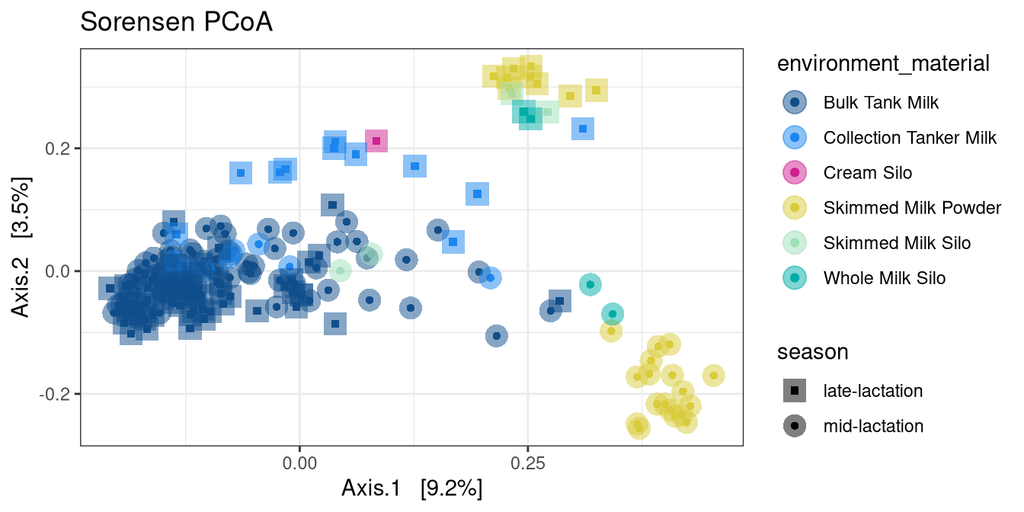

```r
# Plot it: Sorensen PCoA
sorensen_pcoa_plot <-
  plot_ordination(physeq = scaled_physeq,
                ordination = scaled_soren_pcoa,
                color = "environment_material",
                shape = "season",
                title = "Sorensen PCoA") +
  scale_color_manual(values = environment_colors) +
  scale_shape_manual(values = c(15, 16)) +
  geom_point(size = 5, alpha = 0.5, aes(color = environment_material)) +
  theme_bw() +
  theme(legend.position = "right")

sorensen_pcoa_plot
```

### Bray-Curtis

```r
# First, calculate PCoA with Bray
scaled_bray_pcoa <-
  ordinate(physeq = scaled_physeq,
         method = "PCoA",
         distance = "bray", binary = FALSE)

# Take a quick look
str(scaled_bray_pcoa)
```

```
## List of 5
##  $ correction: chr [1:2] "none" "1"
##  $ note      : chr "No correction was applied to the negative eigenvalues"
##  $ values    :'data.frame':  185 obs. of  6 variables:
##   ..$ Eigenvalues   : num [1:185] 9.09 6.69 3.6 2.51 1.96 ...
##   ..$ Relative_eig  : num [1:185] 0.1348 0.0992 0.0533 0.0373 0.029 ...
##   ..$ Rel_corr_eig  : num [1:185] 0.1094 0.0808 0.0439 0.031 0.0244 ...
##   ..$ Broken_stick  : num [1:185] 0.0316 0.0262 0.0234 0.0216 0.0203 ...
##   ..$ Cum_corr_eig  : num [1:185] 0.109 0.19 0.234 0.265 0.29 ...
##   ..$ Cumul_br_stick: num [1:185] 0.0316 0.0578 0.0812 0.1029 0.1231 ...
##  $ vectors   : num [1:185, 1:160] 0.0726 0.2001 -0.0897 -0.0598 0.1552 ...
##   ..- attr(*, "dimnames")=List of 2
##   .. ..$ : chr [1:185] "ERR3141386" "ERR3141387" "ERR3141388" "ERR3141389" ...
##   .. ..$ : chr [1:160] "Axis.1" "Axis.2" "Axis.3" "Axis.4" ...
##  $ trace     : num 67.4
##  - attr(*, "class")= chr "pcoa"
```

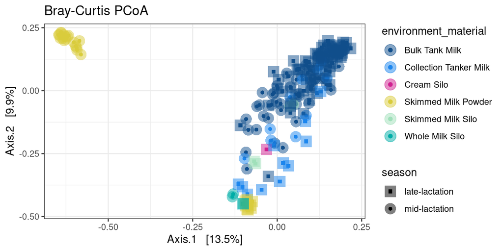

```r
# Plot it: Bray PCoA
bray_pcoa_plot <-
  plot_ordination(physeq = scaled_physeq,
                ordination = scaled_bray_pcoa,
                color = "environment_material",
                shape = "season",
                title = "Bray-Curtis PCoA") +
  scale_color_manual(values = environment_colors) +
  scale_shape_manual(values = c(15, 16)) +
  geom_point(size = 5, alpha = 0.5, aes(color = environment_material)) +
  theme_bw() +
  theme(legend.position = "right")

bray_pcoa_plot
```

### Unweighted-Unifrac

```r
# First, calculate PCoA with unweighted UniFrac
scaled_uwunifrac_pcoa <-
  ordinate(physeq = scaled_physeq,
           method = "PCoA",
           distance = "unifrac",  # change here!
           weighted = FALSE)

# Take a quick look
str(scaled_uwunifrac_pcoa)
```

```
## List of 5
##  $ correction: chr [1:2] "none" "1"
##  $ note      : chr "There were no negative eigenvalues. No correction was applied"
##  $ values    :'data.frame':  184 obs. of  5 variables:
##   ..$ Eigenvalues   : num [1:184] 7.659 2.177 1.114 0.948 0.718 ...
##   ..$ Relative_eig  : num [1:184] 0.1622 0.0461 0.0236 0.0201 0.0152 ...
##   ..$ Broken_stick  : num [1:184] 0.0315 0.0261 0.0233 0.0215 0.0202 ...
##   ..$ Cumul_eig     : num [1:184] 0.162 0.208 0.232 0.252 0.267 ...
##   ..$ Cumul_br_stick: num [1:184] 0.0315 0.0576 0.0809 0.1024 0.1226 ...
##  $ vectors   : num [1:185, 1:184] -0.1144 -0.1713 0.0524 0.0534 -0.0448 ...
##   ..- attr(*, "dimnames")=List of 2
##   .. ..$ : chr [1:185] "ERR3141386" "ERR3141387" "ERR3141388" "ERR3141389" ...
##   .. ..$ : chr [1:184] "Axis.1" "Axis.2" "Axis.3" "Axis.4" ...
##  $ trace     : num 47.2
##  - attr(*, "class")= chr "pcoa"
```

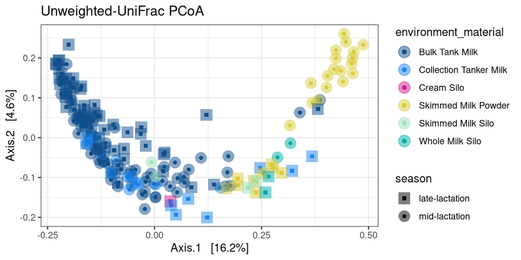

```r
# Plot it: Unweighted UniFrac PCoA
uwunifrac_pcoa_plot <-
  plot_ordination(physeq = scaled_physeq,
                  ordination = scaled_uwunifrac_pcoa,
                  color = "environment_material",
                  shape = "season",
                  title = "Unweighted-UniFrac PCoA") +
  scale_color_manual(values = environment_colors) +
  scale_shape_manual(values = c(15, 16)) +
  geom_point(size = 5, alpha = 0.5, aes(color = environment_material)) +
  theme_bw() +
  theme(legend.position = "right")

uwunifrac_pcoa_plot
```

### Weighted-Unifrac

```r
# First, calculate PCoA with Weighted-UniFrac
scaled_wunifrac_pcoa <-
  ordinate(physeq = scaled_physeq,
           method = "PCoA",
           distance = "unifrac",
           weighted = TRUE)

# Take a quick look
str(scaled_wunifrac_pcoa)
```

```
## List of 5
##  $ correction: chr [1:2] "none" "1"
##  $ note      : chr "No correction was applied to the negative eigenvalues"
##  $ values    :'data.frame':  185 obs. of  6 variables:
##   ..$ Eigenvalues   : num [1:185] 7.41 6.72 1.7 1.3 1.04 ...
##   ..$ Relative_eig  : num [1:185] 0.291 0.2636 0.0669 0.051 0.0408 ...
##   ..$ Rel_corr_eig  : num [1:185] 0.1367 0.1241 0.0337 0.0264 0.0217 ...
##   ..$ Broken_stick  : num [1:185] 0.0316 0.0262 0.0234 0.0216 0.0203 ...
##   ..$ Cum_corr_eig  : num [1:185] 0.137 0.261 0.294 0.321 0.343 ...
##   ..$ Cumul_br_stick: num [1:185] 0.0316 0.0578 0.0812 0.1029 0.1231 ...
##  $ vectors   : num [1:185, 1:104] -0.0125 -0.1631 0.2509 0.0464 -0.1983 ...
##   ..- attr(*, "dimnames")=List of 2
##   .. ..$ : chr [1:185] "ERR3141386" "ERR3141387" "ERR3141388" "ERR3141389" ...
##   .. ..$ : chr [1:104] "Axis.1" "Axis.2" "Axis.3" "Axis.4" ...
##  $ trace     : num 25.5
##  - attr(*, "class")= chr "pcoa"
```

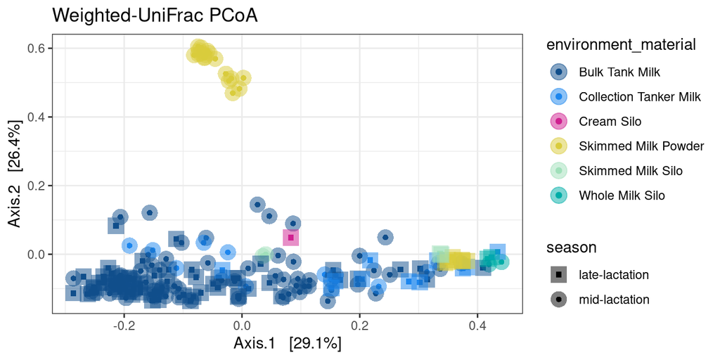

```r
# Plot it: Weighted-UniFrac PCoA
wunifrac_pcoa_plot <-
  plot_ordination(physeq = scaled_physeq,
                  ordination = scaled_wunifrac_pcoa,
                  color = "environment_material",
                  shape = "season",
                  title = "Weighted-UniFrac PCoA") +
  scale_color_manual(values = environment_colors) +
  scale_shape_manual(values = c(15, 16)) +
  geom_point(size = 5, alpha = 0.5, aes(color = environment_material)) +
  theme_bw() +
  theme(legend.position = "right")

wunifrac_pcoa_plot
```

Now show all the PCoA plots together!

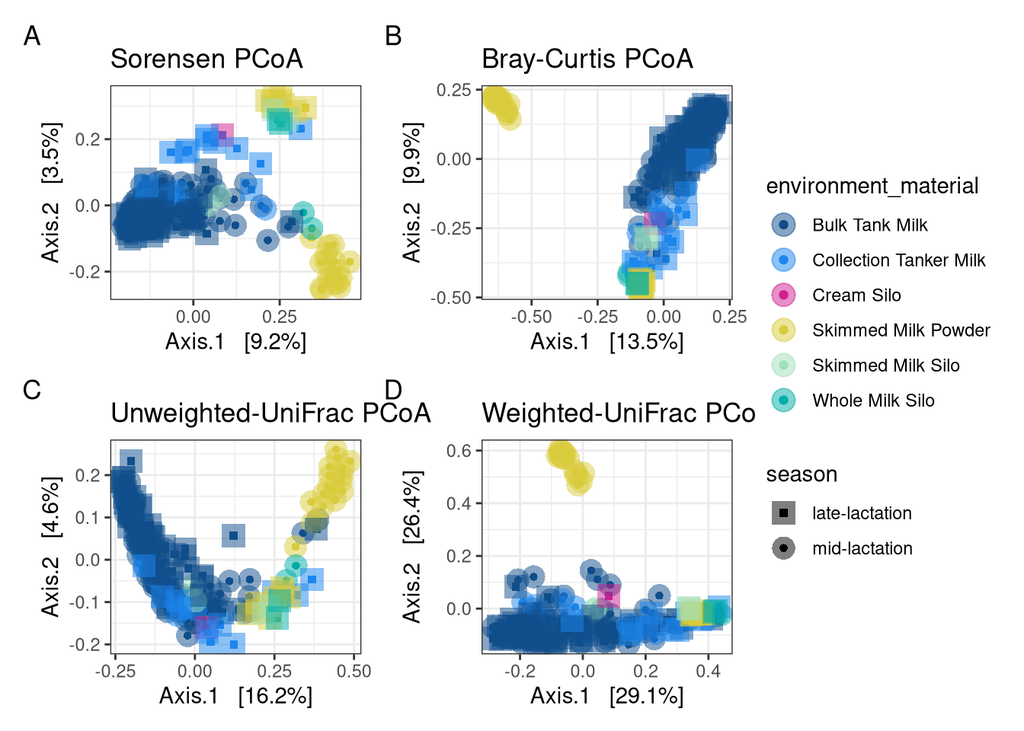

```r
# Show the plots
sorensen_pcoa_plot + bray_pcoa_plot + uwunifrac_pcoa_plot + wunifrac_pcoa_plot +
  plot_layout(guides = "collect") +
  plot_annotation(tag_levels = "A")
```

## NMDS: Non-Metric Multidimensional Scaling

### Sorensen

```r
## SORENSEN
scaled_soren_nmds <-
  ordinate(physeq = scaled_physeq,
         method = "NMDS",
         distance = "bray", binary = TRUE)
```

```
## Square root transformation
## Wisconsin double standardization
## *** Best solution was not repeated -- monoMDS stopping criteria:
##      2: no. of iterations >= maxit
##     18: stress ratio > sratmax
```

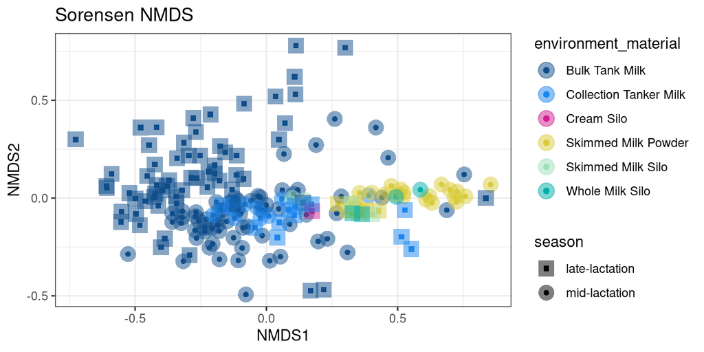

```r
# Plot it!
sorensen_nmds_plot <-
  plot_ordination(physeq = scaled_physeq,
                ordination = scaled_soren_nmds,
                color = "environment_material",
                shape = "season",
                title = "Sorensen NMDS") +
  scale_color_manual(values = environment_colors) +
  scale_shape_manual(values = c(15, 16)) +
  geom_point(size = 5, alpha = 0.5) +
  theme_bw() +
  theme(legend.position = "right")


sorensen_nmds_plot
```

The stress value for Sorensen NMDS was “stress = 0.1762861”. This stress value wasn’t less than 0.1, it was still in the normally acceptable range being less than 0.2.

### Bray-Curtis

```r
#Calculate NMDS with Bray-Curtis
scaled_bray_nmds <-
  ordinate(physeq = scaled_physeq,
         method = "NMDS",
         distance = "bray", binary = FALSE)
```

```
## Square root transformation
## Wisconsin double standardization
## *** Best solution was not repeated -- monoMDS stopping criteria:
##     20: stress ratio > sratmax
```

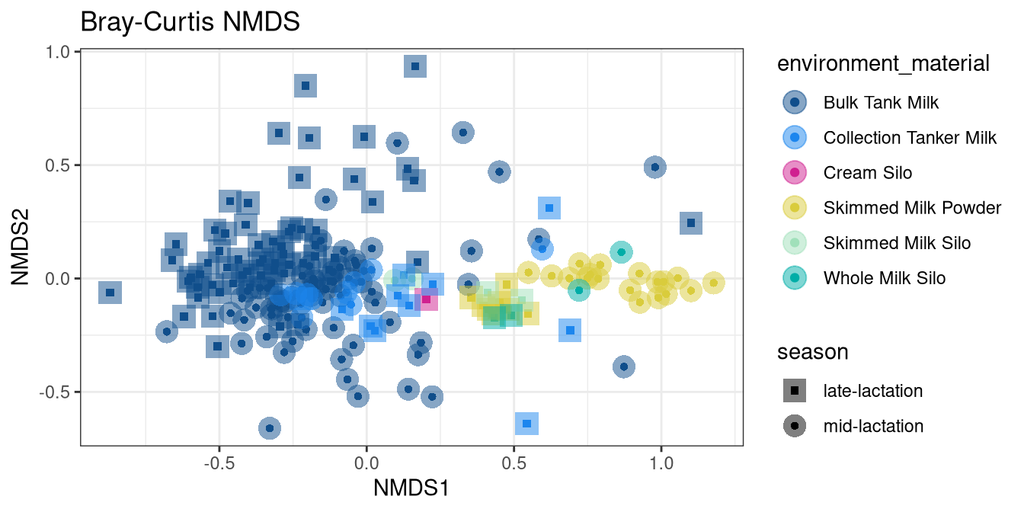

```r
# Plot it: Bray-Curtis NMDS
bray_nmds_plot <-
  plot_ordination(physeq = scaled_physeq,
                ordination = scaled_bray_nmds,
                color = "environment_material",
                shape = "season",
                title = "Bray-Curtis NMDS") +
  scale_color_manual(values = environment_colors) +
  scale_shape_manual(values = c(15, 16)) +
  geom_point(size = 5, alpha = 0.5) +
  theme_bw() +
  theme(legend.position = "right")

bray_nmds_plot
```

The stress value for Bray-Curtis NMDS was “stress = 0.1695472”. This stress value wasn’t less than 0.1, it was still in the normally acceptable range being less than 0.2.

### Unweighted-Unifrac

```r
#Calculate NMDS with Unweighted-Unifrac
scaled_uwunifrac_nmds <-
  ordinate(physeq = scaled_physeq,
         method = "NMDS",
         distance = "unifrac", weighted = FALSE)
```

```
## *** Best solution was not repeated -- monoMDS stopping criteria:
##      1: no. of iterations >= maxit
##     15: stress ratio > sratmax
##      4: scale factor of the gradient < sfgrmin
```

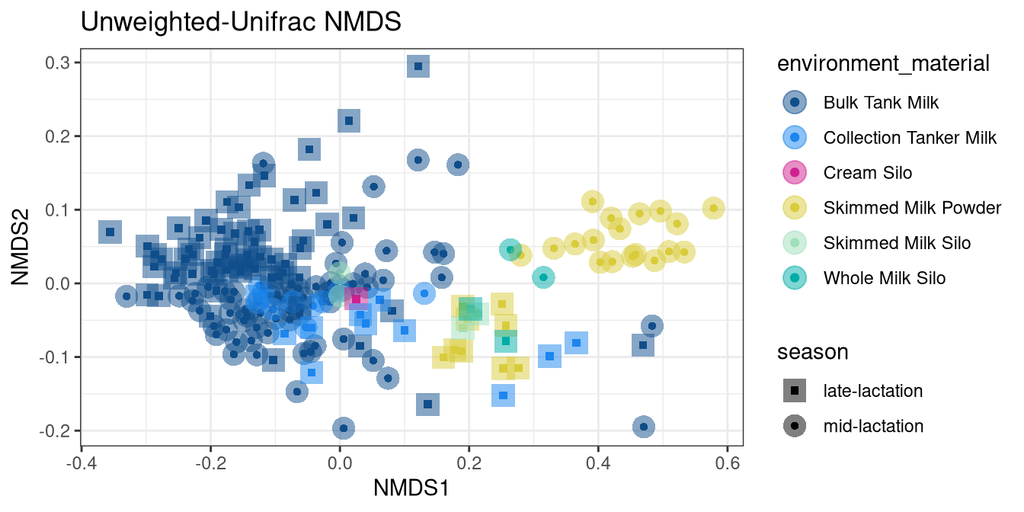

```r
# Plot it: Bray-Curtis NMDS
uwunifrac_nmds_plot <-
  plot_ordination(physeq = scaled_physeq,
                ordination = scaled_uwunifrac_nmds,
                color = "environment_material",
                shape = "season",
                title = "Unweighted-Unifrac NMDS") +
  scale_color_manual(values = environment_colors) +
  scale_shape_manual(values = c(15, 16)) +
  geom_point(size = 5, alpha = 0.5) +
  theme_bw() +
  theme(legend.position = "right")

uwunifrac_nmds_plot
```

### Weighted-Unifrac

```r
#Calculate NMDS with Weighted-Unifrac
scaled_wunifrac_nmds <-
  ordinate(physeq = scaled_physeq,
         method = "NMDS",
         distance = "unifrac", weighted = TRUE)
```

```
## *** Best solution was not repeated -- monoMDS stopping criteria:
##     17: stress ratio > sratmax
##      3: scale factor of the gradient < sfgrmin
```

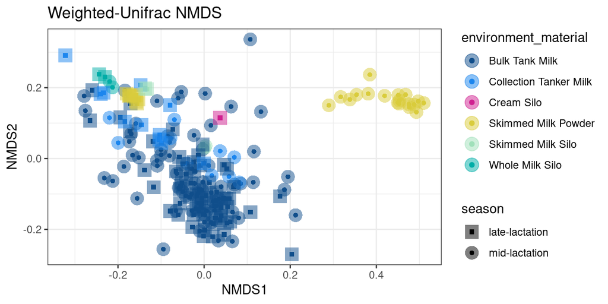

```r
# Plot it: Weighted-Unifrac NMDS
wunifrac_nmds_plot <-
  plot_ordination(physeq = scaled_physeq,
                ordination = scaled_wunifrac_nmds,
                color = "environment_material",
                shape = "season",
                title = "Weighted-Unifrac NMDS") +
  scale_color_manual(values = environment_colors) +
  scale_shape_manual(values = c(15, 16)) +
  geom_point(size = 5, alpha = 0.5) +
  theme_bw() +
  theme(legend.position = "right")

wunifrac_nmds_plot
```

0.1404723

Now combine all the NMDS plots together!

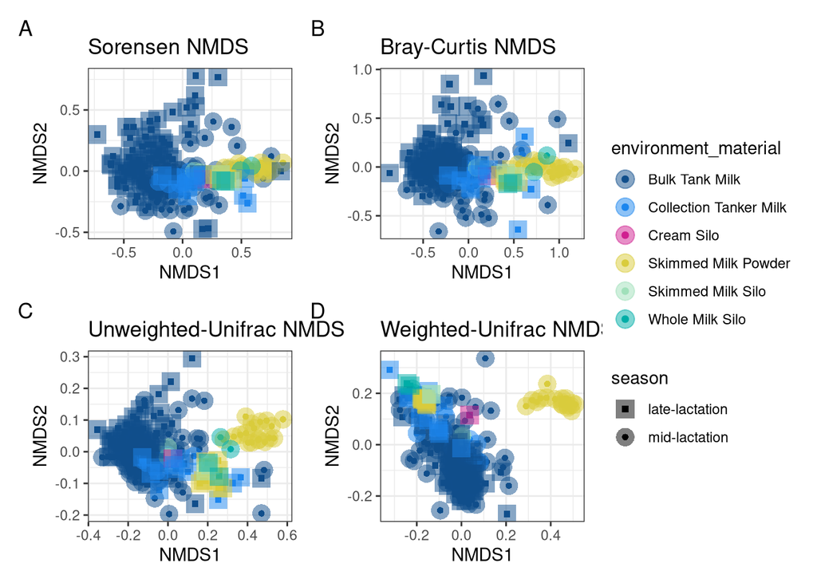

```r
# Show the plots
sorensen_nmds_plot + bray_nmds_plot + uwunifrac_nmds_plot + wunifrac_nmds_plot +
  plot_layout(guides = "collect") +
  plot_annotation(tag_levels = "A")
```

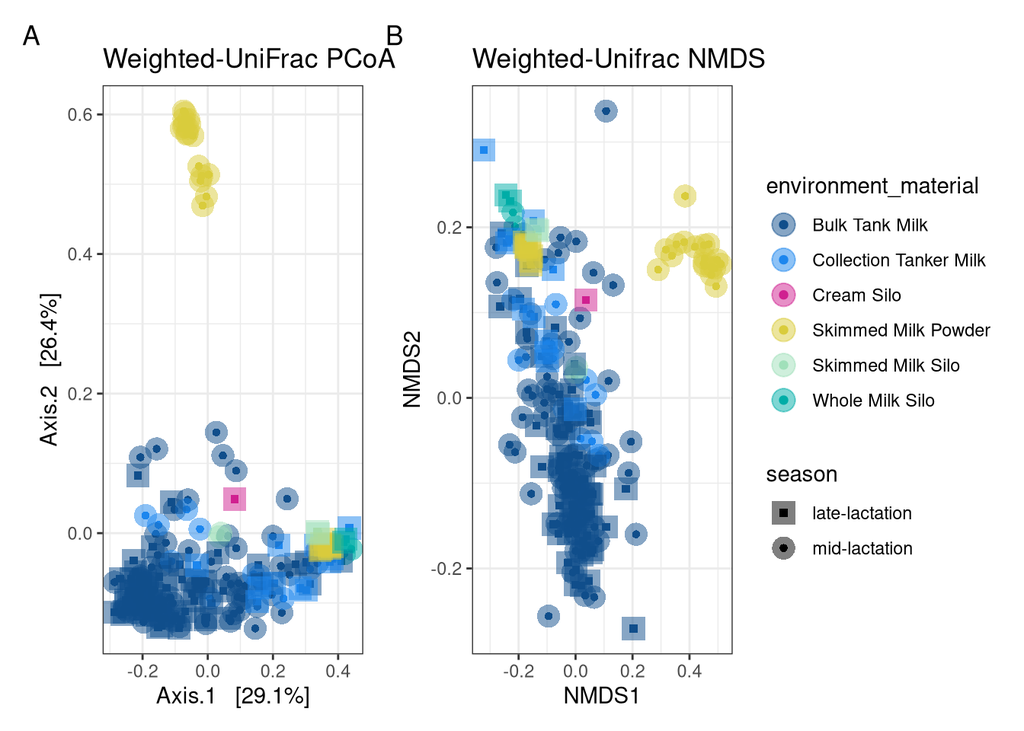

```r
# Show the plots for my presentation
wunifrac_pcoa_plot + wunifrac_nmds_plot +
  plot_layout(guides = "collect") +
  plot_annotation(tag_levels = "A")
```

# Final thoughts and analysis

WOW! SEASON DOES EXPLAIN THE DISTINCT CLUSTERING WITHIN THE SKIMMED MILK POWDER SAMPLES!

The main thing I wanted to see when looking at these new ordinations was if season (represented by shape) would explain the distinct clustering of two groups within the Skimmed Milk Powder samples (and to a lesser extent the Skimmed Milk Silo samples). And we can see that it does!!

Just as a reminder, when I first looked at beta diversity and made the 8 PCoA and NMDS plots I only used dairy sample type as a variable, and I was so confused because I was consistently seeing distinct separate clustering in my skim milk powder samples (yellow here), and to a lesser extent my skim milk silo samples (in light green here).

We talked a lot this semester about doing intuition/gut checks, and felt like something was missing when I initially made these ordinations. I’m so glad I went back and redid parts of my analysis to include seasonality, because it turns out sample type and lactation stage both significantly influence differences between the microbiota of the dairy samples.

Here we can see the skim milk powder samples clustering separately based on season, with the mid-lactation samples essentially having zero overlap with all of the other groups in my other ordination plots

These ordinations ended up being important for guiding my analyses moving forward (in 10_Seasonal_Composition). I shifted my analysis to try and figure out what was driving such distinct clustering in my skim milk powder samples!

# Final info for Reproducibility

## Check Render Time

```r
# Take the time now that we are at the end of the script
end_time <- Sys.time()
end_time
```

```
## [1] "2025-05-02 12:01:08 EDT"
```

```r
# Echo the elapsed time
elapsed_time <- round((end_time - start_time), 3)
elapsed_time
```

```
## Time difference of 11.569 mins
```